# CMSC320 Project 4

Carl Xiong

```python
#!pip install folium
#Only need to install this once.
```

# Starter code

Retrieving all the data from online and importing into a panda dataframe. Also, seperating the location string into two seperate columns.

The Location 1 column is a string of the format (float,float). Using simple string manipulation, we take it apart and create a latitude and longitude column for each row

```python
import folium
import requests
import pandas

arrest_table = pandas.read_csv("http://www.hcbravo.org/IntroDataSci/misc/BPD_Arrests.csv")

arrest_table["race_new"] = arrest_table["sex"]
arrest_table["sex_new"] = arrest_table["race"]
arrest_table["race"] = arrest_table["sex_new"]
arrest_table["sex"] = arrest_table["race_new"]
arrest_table = arrest_table.drop('race_new', 1)
arrest_table = arrest_table.drop('sex_new', 1)

arrest_table = arrest_table[pandas.notnull(arrest_table["Location 1"])]

arrest_table["lat"], arrest_table["long"] = arrest_table["Location 1"].str.split(",").str
arrest_table["lat"] = arrest_table["lat"].str.replace("(", "").astype(float)
arrest_table["long"] = arrest_table["long"].str.replace(")", "").astype(float)

arrest_table.head()
```

|  | arrest | age | race | sex | arrestDate | arrestTime | arrestLocation | incidentOffense | incidentLocation | charge | chargeDescription | district | post | neighborhood | Location 1 | lat | long |
| --- | --- | --- | --- | --- | --- | --- | --- | --- | --- | --- | --- | --- | --- | --- | --- | --- | --- |
| 1 | 11127013.0 | 37 | B | M | 01/01/2011 | 00:01:00 | 2000 Wilkens Ave | 79-Other | Wilkens Av & S Payson St | 1 1425 | Reckless Endangerment \|\| Hand Gun Violation | SOUTHERN | 934.0 | Carrollton Ridge | (39.2814026274, -76.6483635135) | 39.281403 | -76.648364 |
| 2 | 11126887.0 | 46 | B | M | 01/01/2011 | 00:01:00 | 2800 Mayfield Ave | Unknown Offense | NaN | NaN | Unknown Charge | NORTHEASTERN | 415.0 | Belair-Edison | (39.3227699160, -76.5735750473) | 39.322770 | -76.573575 |
| 3 | 11126873.0 | 50 | B | M | 01/01/2011 | 00:04:00 | 2100 Ashburton St | 79-Other | 2100 Ashburton St | 1 1106 | Reg Firearm:Illegal Possession \|\| Hgv | WESTERN | 735.0 | Panway/Braddish Avenue | (39.3117196723, -76.6623546313) | 39.311720 | -76.662355 |
| 4 | 11126968.0 | 33 | B | M | 01/01/2011 | 00:05:00 | 4000 Wilsby Ave | Unknown Offense | 1700 Aliceanna St | NaN | Unknown Charge | NORTHERN | 525.0 | Pen Lucy | (39.3382885254, -76.6045667070) | 39.338289 | -76.604567 |
| 5 | 11127041.0 | 41 | B | M | 01/01/2011 | 00:05:00 | 2900 Spellman Rd | 81-Recovered Property | 2900 Spelman Rd | 1 1425 | Reckless Endangerment \|\| Handgun Violation | SOUTHERN | 924.0 | Cherry Hill | (39.2449886230, -76.6273582432) | 39.244989 | -76.627358 |

```python
map_osm = folium.Map(location=[39.29, -76.61], zoom_start=11)
map_osm
```

[interactive chart not shown]

```python
arrest_table = arrest_table.reset_index(drop=True)
```

# My Code - Basic data processing

Begin processing all the data and adding pop ups onto the map. Each pop up is added using the location data (lat,long) of each arrest. The pop up contains relevant information such as the date, address, and incident offense for that particular arrest.

For this particular example, I set the number of pop ups generated to be 100, however, one could easily modify this limit by changing the while loop parameters.

```python
map_osm = folium.Map(location=[39.29, -76.61], zoom_start=11)
map_osm

#arrest_table.size
#len(arrest_table.index)

#looplen = len(arrest_table.index)
#looplen = 100
i = 0
nummarkers = 0

while nummarkers < 100:
    tempx = arrest_table.at[i,'lat']
    tempy = arrest_table.at[i,'long']
    #folium.Marker([tempx, tempy], popup='Hi <br> lol').add_to(map_osm)
    currIncident = arrest_table.at[i,'incidentOffense']
    currAddress = arrest_table.at[i,'arrestLocation']
    currDate = arrest_table.at[i,'arrestDate']
    currAge = str(arrest_table.at[i,'age'].item())
    currRace = arrest_table.at[i,'race']
    currSex = arrest_table.at[i,'sex']
    info = ('<b>Address</b> : ' + currAddress + '<br> <b>Date</b> : ' + currDate + '<br> <br> <b>Incident</b> : ' + currIncident +
    '<br> <b>Age<b/> : ' + currAge + '<br> <b>Race<b/> : ' + currRace + '<br> <b>Sex</b> : ' + currSex)

    if (currIncident == '87-Narcotics' ):
        folium.Marker(
        location=[tempx, tempy],
        popup=info,
        icon=folium.Icon(color='green')
        ).add_to(map_osm)
        nummarkers += 1
    elif ( currIncident == '4E-Common Assault'):
        folium.Marker(
        location=[tempx, tempy],
        popup=info,
        icon=folium.Icon(color='darkred')
        ).add_to(map_osm)
        nummarkers += 1
    elif ( currIncident == '54-Armed Person'):
        folium.Marker(
        location=[tempx, tempy],
        popup=info,
        icon=folium.Icon(color='red')
        ).add_to(map_osm)
        nummarkers += 1
    elif ( currIncident == '4B-Agg. Asslt.- Cut'):
        folium.Marker(
        location=[tempx, tempy],
        popup=info,
        icon=folium.Icon(color='orange')
        ).add_to(map_osm)
        nummarkers += 1
    elif ( currIncident == '55-Disorderly Person'):
        folium.Marker(
        location=[tempx, tempy],
        popup=info,
        icon=folium.Icon(color='blue')
        ).add_to(map_osm)
        nummarkers += 1

    i = i + 1
```

# Example Output

Pop ups are added onto the map and are color coded. The most common incidents have been assigned a color (Based on visual intution). (if the incident was rare, such as destruction of property or it was Unknown Offense, then I did not add it as a pop-up and also did not match it to a color.)

# Color Rule:

Narcotics - Green

Common Assault - Dark Red

Armed Person - Red

Aggrevated Assault - Orange

Disorderly Person - Blue

### Try it yourself, click on a marker below to display a pop up

```python
map_osm
```

[interactive chart not shown]

```python
arrest_table.head()
```

|  | arrest | age | race | sex | arrestDate | arrestTime | arrestLocation | incidentOffense | incidentLocation | charge | chargeDescription | district | post | neighborhood | Location 1 | lat | long |
| --- | --- | --- | --- | --- | --- | --- | --- | --- | --- | --- | --- | --- | --- | --- | --- | --- | --- |
| 0 | 11127013.0 | 37 | B | M | 01/01/2011 | 00:01:00 | 2000 Wilkens Ave | 79-Other | Wilkens Av & S Payson St | 1 1425 | Reckless Endangerment \|\| Hand Gun Violation | SOUTHERN | 934.0 | Carrollton Ridge | (39.2814026274, -76.6483635135) | 39.281403 | -76.648364 |
| 1 | 11126887.0 | 46 | B | M | 01/01/2011 | 00:01:00 | 2800 Mayfield Ave | Unknown Offense | NaN | NaN | Unknown Charge | NORTHEASTERN | 415.0 | Belair-Edison | (39.3227699160, -76.5735750473) | 39.322770 | -76.573575 |
| 2 | 11126873.0 | 50 | B | M | 01/01/2011 | 00:04:00 | 2100 Ashburton St | 79-Other | 2100 Ashburton St | 1 1106 | Reg Firearm:Illegal Possession \|\| Hgv | WESTERN | 735.0 | Panway/Braddish Avenue | (39.3117196723, -76.6623546313) | 39.311720 | -76.662355 |
| 3 | 11126968.0 | 33 | B | M | 01/01/2011 | 00:05:00 | 4000 Wilsby Ave | Unknown Offense | 1700 Aliceanna St | NaN | Unknown Charge | NORTHERN | 525.0 | Pen Lucy | (39.3382885254, -76.6045667070) | 39.338289 | -76.604567 |
| 4 | 11127041.0 | 41 | B | M | 01/01/2011 | 00:05:00 | 2900 Spellman Rd | 81-Recovered Property | 2900 Spelman Rd | 1 1425 | Reckless Endangerment \|\| Handgun Violation | SOUTHERN | 924.0 | Cherry Hill | (39.2449886230, -76.6273582432) | 39.244989 | -76.627358 |

# Goals

I want to be able to view the data separately on the map. Allowing the user to see only pop ups that are relevant to a certain category, whether if the user wanted to see only crimes located in the central district or whether if the user wanted to see what type of crime was prominent in a certain area, narcotics related, assault, etc.

Here are some examples of what that would look like.

```python
central_table = arrest_table.loc[arrest_table['district'] == 'CENTRAL']
```

```python
central_table = central_table.reset_index(drop=True)
```

```python
central_table.head()
```

|  | arrest | age | race | sex | arrestDate | arrestTime | arrestLocation | incidentOffense | incidentLocation | charge | chargeDescription | district | post | neighborhood | Location 1 | lat | long |
| --- | --- | --- | --- | --- | --- | --- | --- | --- | --- | --- | --- | --- | --- | --- | --- | --- | --- |
| 0 | 11126919.0 | 45 | B | M | 01/01/2011 | 00:54:00 | 1700 Druid Hill Ave | 4E-Common Assault | 1700 Druid Hill Av | 1 1415 | Asslt-Sec Degree \|\| Assault | CENTRAL | 132.0 | Upton | (39.3054190021, -76.6328383753) | 39.305419 | -76.632838 |
| 1 | 11127135.0 | 45 | W | M | 01/01/2011 | 02:00:00 | 300 Light St | 4E-Common Assault | 300 Light St | 1 0573 | Cds: Possession-Marihuana \|\| Assault On Police | CENTRAL | 112.0 | Inner Harbor | (39.2854382678, -76.6134734784) | 39.285438 | -76.613473 |
| 2 | 11126955.0 | 20 | B | M | 01/01/2011 | 02:20:00 | 900 Myrtle Ave | 87-Narcotics | 900 Myrtle Av | 1 0573 | Cds: Possession-Marihuana \|\| Possession Of Mar... | CENTRAL | 122.0 | Heritage Crossing | (39.2953767825, -76.6288329196) | 39.295377 | -76.628833 |
| 3 | 11127359.0 | 28 | B | M | 01/02/2011 | 17:45:00 | 500 Dolphin St | 55-Disorderly Person | 500 Dolphin St | 2 0050 | Dis.Erly Conduct \|\| Disorderly | CENTRAL | 124.0 | Upton | (39.3006953035, -76.6281334931) | 39.300695 | -76.628133 |
| 4 | 11127350.0 | 38 | B | M | 01/02/2011 | 19:30:00 | 200 E Fayette St | 75-Destruct. Of Property | 200 N Calvert St | NaN | Unknown Charge | CENTRAL | 111.0 | Downtown | (39.2904307774, -76.6120702823) | 39.290431 | -76.612070 |

```python
map_osm = folium.Map(location=[39.29, -76.61], zoom_start=11)
map_osm

i = 0

looplen = len(arrest_table.index)
looplen = 100
nummarkers = 0
while nummarkers < 200:
    tempx = central_table.at[i,'lat']
    tempy = central_table.at[i,'long']
    #folium.Marker([tempx, tempy], popup='Hi <br> lol').add_to(map_osm)
    currIncident = central_table.at[i,'incidentOffense']
    currAddress = central_table.at[i,'arrestLocation']
    currDate = central_table.at[i,'arrestDate']
    currAge = str(central_table.at[i,'age'].item())
    currRace = central_table.at[i,'race']
    currSex = central_table.at[i,'sex']
    info = ('<b>Address</b> : ' + currAddress + '<br> <b>Date</b> : ' + currDate + '<br> <br> <b>Incident</b> : ' + currIncident +
    '<br> <b>Age<b/> : ' + currAge + '<br> <b>Race<b/> : ' + currRace + '<br> <b>Sex</b> : ' + currSex)

    if (currIncident == '87-Narcotics' ):
        folium.Marker(
        location=[tempx, tempy],
        popup=info,
        icon=folium.Icon(color='green')
        ).add_to(map_osm)
    elif ( currIncident == '4E-Common Assault'):
        folium.Marker(
        location=[tempx, tempy],
        popup=info,
        icon=folium.Icon(color='darkred')
        ).add_to(map_osm)
    elif ( currIncident == '54-Armed Person'):
        folium.Marker(
        location=[tempx, tempy],
        popup=info,
        icon=folium.Icon(color='red')
        ).add_to(map_osm)
    elif ( currIncident == '4B-Agg. Asslt.- Cut'):
        folium.Marker(
        location=[tempx, tempy],
        popup=info,
        icon=folium.Icon(color='orange')
        ).add_to(map_osm)
    elif ( currIncident == '55-Disorderly Person'):
        folium.Marker(
        location=[tempx, tempy],
        popup=info,
        icon=folium.Icon(color='blue')
        ).add_to(map_osm)

    nummarkers += 1
    i = i + 1
```

# Example 1 - Sorting based on location/district

Example output for a particular map if the user only displayed by selecting "CENTRAL" as the district.

```python
map_osm
```

[interactive chart not shown]

```python
prostitute_table = arrest_table.loc[arrest_table['incidentOffense'] == '55A-Prostitution']
prostitute_table = prostitute_table.reset_index(drop=True)
```

```python
prostitute_table.head()
```

|  | arrest | age | race | sex | arrestDate | arrestTime | arrestLocation | incidentOffense | incidentLocation | charge | chargeDescription | district | post | neighborhood | Location 1 | lat | long |
| --- | --- | --- | --- | --- | --- | --- | --- | --- | --- | --- | --- | --- | --- | --- | --- | --- | --- |
| 0 | 11127744.0 | 26 | W | F | 01/03/2011 | 17:20:00 | 200 E Pontiac Ave | 55A-Prostitution | 200 Pontiac Av | 1 1093 | Prostitution-General \|\| Prostitution | SOUTHERN | 912.0 | Brooklyn | (39.2370295156, -76.6085232692) | 39.237030 | -76.608523 |
| 1 | 11127798.0 | 24 | W | M | 01/03/2011 | 18:45:00 | 1000 S Carey St | 55A-Prostitution | 100 S Carey St | 1 1093 | Prostitution-General \|\| Prostitution | SOUTHERN | 931.0 | Washington Village | (39.2817178080, -76.6368245492) | 39.281718 | -76.636825 |
| 2 | 11128617.0 | 26 | B | M | 01/04/2011 | 11:30:00 | 1500 N Gilford Ave | 55A-Prostitution | 4900 Sinclair Ln | 1 1093 | Prostitution-General \|\| Prostitution | CENTRAL | 142.0 | Greenmount West | (39.3069463999, -76.6121759482) | 39.306946 | -76.612176 |
| 3 | 11128659.0 | 58 | B | F | 01/04/2011 | 23:45:00 | 300 21 St | 55A-Prostitution | 500 E 25Th St | 1 1093 | Prostitution-General \|\| Prostitution | EASTERN | 314.0 | Barclay | (39.3134351960, -76.6122794917) | 39.313435 | -76.612279 |
| 4 | 11128620.0 | 41 | B | F | 01/05/2011 | 00:05:00 | 300 W 27 St | 55A-Prostitution | 1300 E 25Th St | 1 1093 | Prostitution-General \|\| Prostitution | NORTHERN | 512.0 | Remington | (39.3202150674, -76.6210343310) | 39.320215 | -76.621034 |

```python
map_osm = folium.Map(location=[39.29, -76.61], zoom_start=11)
i = 0
nummarkers = 0

while nummarkers < 20:
    tempx = prostitute_table.at[i,'lat']
    tempy = prostitute_table.at[i,'long']
    #folium.Marker([tempx, tempy], popup='Hi <br> lol').add_to(map_osm)
    currIncident = prostitute_table.at[i,'incidentOffense']
    currAddress = prostitute_table.at[i,'arrestLocation']
    currDate = prostitute_table.at[i,'arrestDate']
    currAge = str(prostitute_table.at[i,'age'].item())
    currRace = prostitute_table.at[i,'race']
    currSex = prostitute_table.at[i,'sex']
    info = ('<b>Address</b> : ' + currAddress + '<br> <b>Date</b> : ' + currDate + '<br> <br> <b>Incident</b> : ' + currIncident +
    '<br> <b>Age<b/> : ' + currAge + '<br> <b>Race<b/> : ' + currRace + '<br> <b>Sex</b> : ' + currSex)

    if (currIncident == '55A-Prostitution' ):
        folium.Marker(
        location=[tempx, tempy],
        popup=info,
        icon=folium.Icon(color='pink')
        ).add_to(map_osm)
        nummarkers += 1

    i = i + 1
```

# Example 2 - Sorting based on incidentOffense

Example output if user selected to group crimes based on incidentOffense. The given map displays crimes relating to prostitution.

Prostitution is one of the more unique cases in that it is very location centered. Because of this, one can predict a general trend in areas in which prositution will occur again.

```python
map_osm
```

[interactive chart not shown]

## Example 2.1 - Utilizing the given data.

Because of how relevant location is to prostitution, we can attempt to cluster each point to an area in order to produce a "mean area". We will atempt this by using k-means clustering from scikit learn.

First we need the data points that we will perform k-means clustering on. So we extract the long lat data from the crime table.

```python
import numpy
```

```python
data = numpy.array([[1,2]])

i = 0
while i < 20:
    tempy = prostitute_table.at[i,'lat']
    tempx = prostitute_table.at[i,'long']

    data = numpy.append(data, [[tempx,tempy]], axis = 0)

    i = i + 1

data = numpy.delete(data,0,0)
data
```

```
array([[-76.60852327,  39.23702952],
       [-76.63682455,  39.28171781],
       [-76.61217595,  39.3069464 ],
       [-76.61227949,  39.3134352 ],
       [-76.62103433,  39.32021507],
       [-76.55992267,  39.34080419],
       [-76.59794298,  39.31728214],
       [-76.59794298,  39.31728214],
       [-76.59299333,  39.23346175],
       [-76.63962422,  39.28447246],
       [-76.60411095,  39.3162099 ],
       [-76.662912  ,  39.27666718],
       [-76.5674652 ,  39.29081007],
       [-76.58177155,  39.29203125],
       [-76.58452163,  39.29666356],
       [-76.67691533,  39.31738111],
       [-76.68244528,  39.32964751],
       [-76.67695668,  39.315294  ],
       [-76.65813661,  39.25530257],
       [-76.6378751 ,  39.28331255]])
```

We have our coordinate points, lets plot it out on a scatter plot

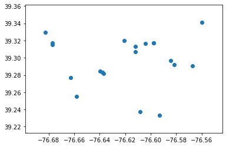

```python
import matplotlib.pyplot as plt

plt.scatter(data[:,0],data[:,1], label='True Position')
```

```python
from sklearn.cluster import KMeans
kmeans = KMeans(n_clusters=6)
kmeans.fit(data)

print(kmeans.cluster_centers_)
```

```
[[-76.6470745   39.27629451]
 [-76.60758111  39.31522848]
 [-76.67877243  39.32077421]
 [-76.57791946  39.29316829]
 [-76.6007583   39.23524563]
 [-76.55992267  39.34080419]]
```

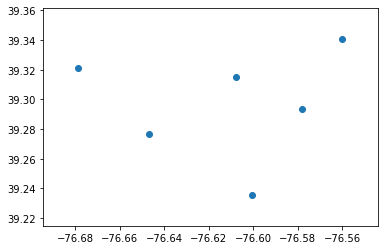

```python
plt.scatter(kmeans.cluster_centers_[:,0],kmeans.cluster_centers_[:,1])
```

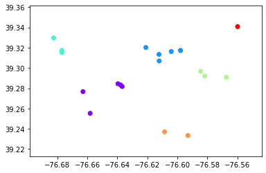

```python
plt.scatter(data[:,0],data[:,1], c=kmeans.labels_, cmap='rainbow')
```

## K-Means clustering

Using scikit learn's clustering library, we can group the locations for prostitution together. These groupings might be representative of different organizations that are running the prostitution services.

Going back to the map, we can plot the "center" for each cluster of prostitution crime.

```python
print(kmeans.cluster_centers_)
```

```
[[-76.6470745   39.27629451]
 [-76.60758111  39.31522848]
 [-76.67877243  39.32077421]
 [-76.57791946  39.29316829]
 [-76.6007583   39.23524563]
 [-76.55992267  39.34080419]]
```

```python
map_osm = folium.Map(location=[39.29, -76.61], zoom_start=11)

i = 0
while i < 6:
    temp = kmeans.cluster_centers_[i]
    tempy = temp[0]
    tempx = temp[1]

    info = "Cluster " + str(i)

    folium.Marker(
    location=[tempx, tempy],
    popup=info,
    icon=folium.Icon(color='black')
    ).add_to(map_osm)

    i = i + 1

map_osm
```

[interactive chart not shown]

# Future Ideas and features

Another idea I came up with would be to implement a slider bar which interacted with the time/date of each arrest. The user would be able to slide the max and the min of the sliders around to see the most prominent arrests during a given time period. (E.G. during christmas, maybe less crimes happens, and during the summer, when kids are out of school, maybe petty theft would increase.)